# Single tissue models in MoBi

Jim Hughes

Monday, 18 June 2018

### Base Evaluation of Method

PKSim is not designed for use with single tissue models, therefore a method was designed to convert PKSim models for use as single tissue models using MoBi.

The observed data for the venous blood was used as the input of the model. The equation used for this forcing function were made up of a sum of exponentials.

The sum of exponentials were fitted to dose normalised data. The forcing function is multiplied by weight of the mouse (W) and the dose (D) to remove the dose normalisation. The units of the function are in umol/L as these are the units of concentrations used in MoBi.

$$FF(t) = D*W*(e^{-3.81*10^{-7}t - 1.34} + e^{-0.0145t+3.02} + e^{-0.101t+5.99})$$

The plot below shows the plasma concentrations for each of the four dosage ranges (0.5, 1.5, 5 and 10 mg/kg). The mean observed plasma concentrations obtained from pre-clinical studies are represented by the blue dots, while the concentrations predicted by the sum of exponentials are represented by the red line.

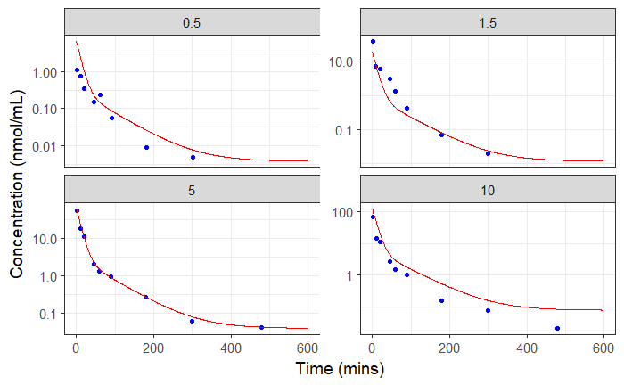

These sum of exponentials were used as the concentration for the afferent blood vessel plasma and blood cells (arterial blood for most tissues, venous blood for lung).

The forcing function is used to dictate the concentrations in both plasma and blood cells, however MoBi requires the amount of drug in each compartment when at equilibrium. Therefore the forcing function is multiplied by the volume of each compartment. The drug amount given to the blood cell compartment is also multiplied by the partition coefficient between blood cells and plasma to ensure that both compartments are in equilibrium during simulation.

$$C_{pls} = V_{pls}*FF(t)$$
$$C_{bc} = V_{bc}*K_{bc}*FF(t)$$

When implemented in MoBi with no corrections concentrations are not recreated faithfully, with this phenomenon being worse in some tissues.

The plot below shows the concentrations of the afferent blood vessel in four different tissues. The concentrations determined by the forcing function are represented by the red line, while concentrations that resulted from MoBi simulations are represented in green.

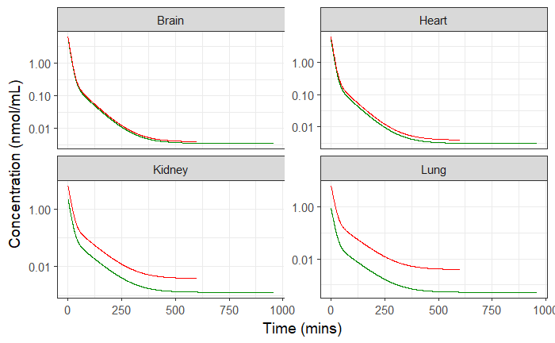

### Sensitivity Analysis

To determine what components of the model were causing these issues a sensitivity analysis was performed. This involves perturbing parameters by a small amount and evaluating the impact this has on pharmacokinetic metrics such as AUC and Cmax. If the forcing function is working perfectly, you would expect the most important parameters to be those responsible for the forcing function.

Sensitivity analysis was run at multiple simulation resolutions to determine if this also had an impact on pharmacokinetic metrics.

The most sensitive model parameters for changes in Cmax were Afferent Blood Vessel Volume and Tissue Blood Flow. Volume should not have impacted Cmax in the sensitivity analysis, as the dose was linked to afferent blood volume to ensure the Cmax was the same independent of blood vessel volume.

The most sensitive model parameters for changes in AUC were also Afferent Blood Vessel Volume and Tissue Blood Flow. Blood Flow should not have impacted AUC in the sensitivity analysis, as the decrease in afferent blood concentrations were dictated by a forcing function, not by the drug flowing out of the compartment.

As these parameters effect both Cmax and AUC it is somewhat safe to assume that Cmax and AUC are sensitive to these parameters as they affect concentrations in the compartment.

Below shows the sensitivity indicies (Value column) for the Heart tissue.

| Tissue | Parameter | Resolution | Value |
| --- | --- | --- | --- |
| Heart | Blood Volume | 5.20 | 0.24 |
| Heart | Blood Flow | 5.20 | -0.24 |
| Heart | Blood Volume | 2.60 | 0.47 |
| Heart | Blood Flow | 2.60 | -0.47 |
| Heart | Blood Volume | 1.30 | 0.94 |
| Heart | Blood Flow | 1.30 | -0.94 |
| Heart | Blood Volume | 0.65 | 1.88 |
| Heart | Blood Flow | 0.65 | -1.88 |
| Heart | Blood Volume | 0.33 | 3.74 |
| Heart | Blood Flow | 0.33 | -3.74 |

Interestingly the two parameters impacted the metrics by the same amount and there were no other influential parameters. The image below shows the sensitivity index plotted against the simulation interval for each tissue.

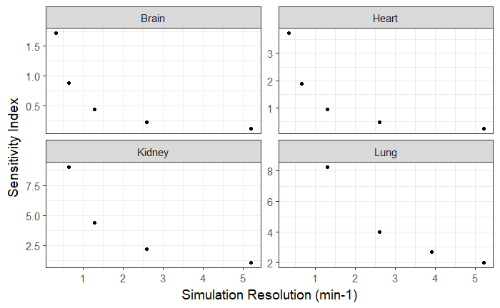

There is an obvious $y = 1/x$ relationship between these two variables. The transformed data is plotted below with the slope values. The slopes correspond with the elimiationn rate constant determined from Tissue Blood Flow and Afferent Blood Volume.

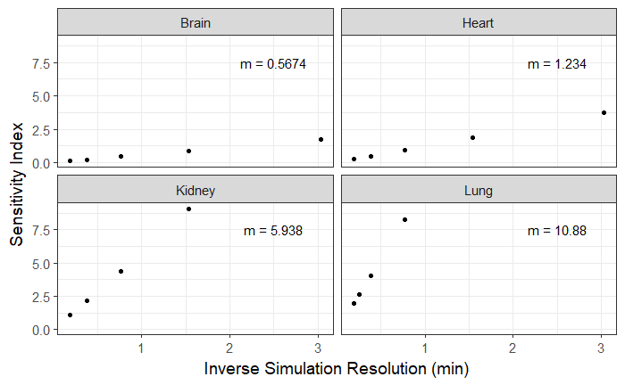

| Tissue | Tissue.Blood.Flow | Afferent.Blood.Volume | k |
| --- | --- | --- | --- |
| Brain | 0.0001782 | 0.0003127 | 0.5697 |
| Heart | 0.0003837 | 0.0003127 | 1.2270 |
| Kidney | 0.0017820 | 0.0003127 | 5.6970 |
| Lung | 0.0075000 | 0.0007192 | 10.4300 |

### Simulation Method Analysis

To further explore how the elimination rate constant affected model predictions the forcing function was implemented in a single-tissue model, where the tissue blood flow was set to zero.

| TIME | sim.pls | sim.bc | sumexp.pls | sumexp.bc |
| --- | --- | --- | --- | --- |
| 0.0000000 | 0.000000 | 0.000000 | 6.316041 | 3.018219 |
| 0.1920384 | 6.316041 | 3.018219 | 6.199358 | 2.962460 |
| 0.3840768 | 6.199358 | 2.962460 | 6.084913 | 2.907771 |
| 0.5761153 | 6.084913 | 2.907771 | 5.972661 | 2.854129 |
| 0.7681536 | 5.972661 | 2.854129 | 5.862561 | 2.801516 |
| 0.9601920 | 5.862561 | 2.801516 | 5.754571 | 2.749912 |

As can be seen the values in the simulation lag behind the true values. The equation below describes this simplified model, where $C$ is the simulated concentration, $FF$ is the forcing function, $t$ is time and $T$ represents the simulation resolution.

$$C(t) = FF(t-\frac{1}{T})$$

To correct for this the $\frac{1}{T}$ was added to $t$ in the forcing function equation.

$$FF(t) = e^{-m(t+\frac{1}{T})+c}$$

The simulations for the simplified model also inform how the forcing function is implemented. As $C(t)$ lags behind $FF(t)$ it becomes apparent that the order of operations during simulation of a full single-tissue model are:

1. Set $t$ to zero and begin simulation
2. Report $C(t)$ in compartment at time $t$
3. Calculate $FF(t)$ and update $C(t)$
4. Add $\frac{1}{T}$ to $t$
5. Potential loss of drug?
6. Return to step 2

It was hypothesised that the drug was lost during step 5. Therefore the equation below was used to represent $C(t)$ in a single-tissue model, where $\epsilon$ represents the drug lost in step 5.

$$C(t) = FF(t-\frac{1}{T})+\epsilon$$

To better understand the drug loss, it was calculated by rearranging this equation.

$$\epsilon = C(t) - FF(t-\frac{1}{T})$$

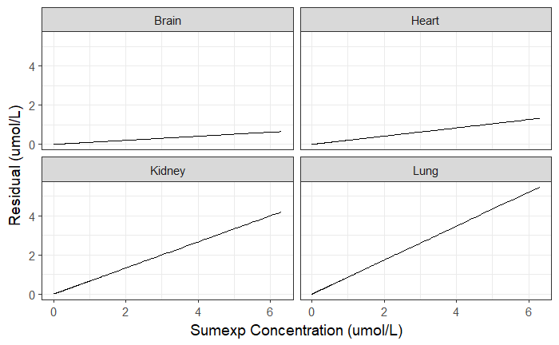

| TISSUE | CI90lo | Mean | CI90hi |
| --- | --- | --- | --- |
| Brain | 0.1036 | 0.1036 | 0.1037 |
| Heart | 0.2102 | 0.2102 | 0.2103 |
| Kidney | 0.6653 | 0.6655 | 0.6657 |
| Lung | 0.8653 | 0.8653 | 0.8654 |

During step 5 an amount of drug is lost from the afferent blood vessel that is dependent on the tissue blood flow rate, the blood volume and the simulation interval. It is assumed that this is due to passive diffusion between compartments. The differential equations for this process are:

$$\frac{dA_{pls}}{dt}=-Q*(1-HCT)*C_{pls}$$
$$\frac{dC_{pls}}{dt}=-\frac{Q*(1-HCT)*C_{pls}}{V_{pls}}$$
$$\frac{dC_{pls}}{dt}=-\frac{Q*(1-HCT)*C_{pls}}{V_{blood}*(1-HCT)}$$
$$\frac{dC_{pls}}{dt}=-\frac{Q*C_{pls}}{V_{blood}}$$
This is just a simple first order kinetic reaction, where $C_0$ is equal to $FF(t)$.
$$C=C_0*e^{-kt}$$
$$C_{pls}=FF(t-\frac1T)*e^{-\frac{Q}{V}\frac{1}{T}}$$
$$\epsilon=FF(t-\frac1T)*(e^{-\frac{Q}{V}\frac{1}{T}}-1)$$
To check if this is correct we can use this equation to calculate the value for $\epsilon$ and observe if they are on the line of identity.

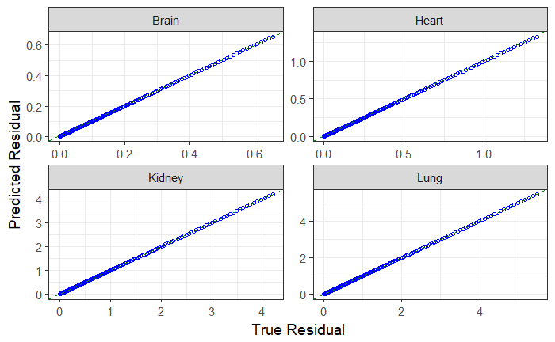

The residuals are never off by more than 1%, meaning this equation describes the drug loss accurately. Therefore the plot below represents what is occuring.

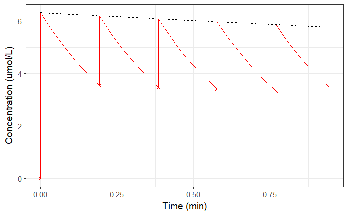

### Fixing One Problem…

Considering all of this we can adjust the input to counteract the intrinsic problems with the simulation to give correct values from the forcing function. First we use $t+\frac1T$ in $FF(t)$ to counteract the input lag. Then we divide the value by $e^{-\frac{Q}{V}\frac{1}{T}}$. This makes our new input $I(t)$, which results in $C(t)$ and $FF(t)$ being equivalent.

$$I(t)=\frac{FF(t+\frac1T)}{e^{-\frac{Q}{V}\frac{1}{T}}}$$
$$C(t)=I(t-\frac1T)*e^{-\frac{Q}{V}\frac{1}{T}}$$
$$\therefore C(t) = FF(t)$$

However this only solves the problem of the afferent concentrations being incorrect. A single-tissue model is used to modify model parameters so that the tissue concentrations match the observed concentrations. Therefore it doesn’t matter if the forcing function is being applied properly if it results in incorrect predictions in the tissue.

To check if tissue concentrations were being simulated faithfully, a PKSim simulation was made, with the afferent blood vessel concentrations being fit with a sum of exponential equation. This was then used to create a single-tissue model aiming to recreate the PKSim simulation results.

Therefore a middle ground needs to be used.

$$I(t)=\frac{FF(t+\frac1T)+\frac{FF(t+\frac1T)}{e^{-\frac{Q}{V}\frac{1}{T}}}}{2}$$
$$C(t)=I(t-\frac1T)*e^{-\frac{Q}{V}\frac{1}{T}}$$
$$\therefore C(t)=\frac{FF(t)*e^{-\frac{Q}{V}\frac{1}{T}}+FF(t)}{2}$$